# Project STA 541

```python
## Getting the data Car_Insurance_Claim
import pandas as pd

df= pd. read_csv("..../Datasets/Car_Insurance_Claim.csv")

## 10000 entries and 19 columns
```

```python
df.head()
```

|  | ID | AGE | GENDER | RACE | DRIVING_EXPERIENCE | EDUCATION | INCOME | CREDIT_SCORE | VEHICLE_OWNERSHIP | VEHICLE_YEAR | MARRIED | CHILDREN | POSTAL_CODE | ANNUAL_MILEAGE | VEHICLE_TYPE | SPEEDING_VIOLATIONS | DUIS | PAST_ACCIDENTS | OUTCOME |
| --- | --- | --- | --- | --- | --- | --- | --- | --- | --- | --- | --- | --- | --- | --- | --- | --- | --- | --- | --- |
| 0 | 569520 | 65+ | female | majority | 0-9y | high school | upper class | 0.629027 | 1.0 | after 2015 | 0.0 | 1.0 | 10238 | 12000.0 | sedan | 0 | 0 | 0 | 0.0 |
| 1 | 750365 | 16-25 | male | majority | 0-9y | none | poverty | 0.357757 | 0.0 | before 2015 | 0.0 | 0.0 | 10238 | 16000.0 | sedan | 0 | 0 | 0 | 1.0 |
| 2 | 199901 | 16-25 | female | majority | 0-9y | high school | working class | 0.493146 | 1.0 | before 2015 | 0.0 | 0.0 | 10238 | 11000.0 | sedan | 0 | 0 | 0 | 0.0 |
| 3 | 478866 | 16-25 | male | majority | 0-9y | university | working class | 0.206013 | 1.0 | before 2015 | 0.0 | 1.0 | 32765 | 11000.0 | sedan | 0 | 0 | 0 | 0.0 |
| 4 | 731664 | 26-39 | male | majority | 10-19y | none | working class | 0.388366 | 1.0 | before 2015 | 0.0 | 0.0 | 32765 | 12000.0 | sedan | 2 | 0 | 1 | 1.0 |

```python
df.info()
```

```
<class 'pandas.core.frame.DataFrame'>
RangeIndex: 10000 entries, 0 to 9999
Data columns (total 19 columns):
 #   Column               Non-Null Count  Dtype
---  ------               --------------  -----
 0   ID                   10000 non-null  int64
 1   AGE                  10000 non-null  object
 2   GENDER               10000 non-null  object
 3   RACE                 10000 non-null  object
 4   DRIVING_EXPERIENCE   10000 non-null  object
 5   EDUCATION            10000 non-null  object
 6   INCOME               10000 non-null  object
 7   CREDIT_SCORE         9018 non-null   float64
 8   VEHICLE_OWNERSHIP    10000 non-null  float64
 9   VEHICLE_YEAR         10000 non-null  object
 10  MARRIED              10000 non-null  float64
 11  CHILDREN             10000 non-null  float64
 12  POSTAL_CODE          10000 non-null  int64
 13  ANNUAL_MILEAGE       9043 non-null   float64
 14  VEHICLE_TYPE         10000 non-null  object
 15  SPEEDING_VIOLATIONS  10000 non-null  int64
 16  DUIS                 10000 non-null  int64
 17  PAST_ACCIDENTS       10000 non-null  int64
 18  OUTCOME              10000 non-null  float64
dtypes: float64(6), int64(5), object(8)
memory usage: 1.4+ MB
```

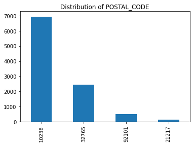

```python
## Checking the POSTAL_CODE
df['POSTAL_CODE'].value_counts().plot(kind="bar", title="Distribution of POSTAL_CODE")
## We need to POSTAL_CODE to categorical datatype as there are only four postal codes.
## But we cannot predict the response for new postal codes with this model.
```

```python
## Changing data types of columns
df["AGE"]=df["AGE"].astype("category")
df["GENDER"]=df["GENDER"].astype("category")
df["RACE"]=df["RACE"].astype("category")
df["DRIVING_EXPERIENCE"]=df["DRIVING_EXPERIENCE"].astype("category")
df["EDUCATION"]=df["EDUCATION"].astype("category")
df["INCOME"]=df["INCOME"].astype("category")
df["VEHICLE_YEAR"]=df["VEHICLE_YEAR"].astype("category")
df["VEHICLE_TYPE"]=df["VEHICLE_TYPE"].astype("category")
df["INCOME"]=df["INCOME"].astype("category")
df["POSTAL_CODE"]=df["POSTAL_CODE"].astype("category")
df["MARRIED"]=df["MARRIED"].astype("category")
df["OUTCOME"]=df["OUTCOME"].astype("category")
df["VEHICLE_OWNERSHIP"]=df["VEHICLE_OWNERSHIP"].astype("category")
df["CHILDREN"]=df["CHILDREN"].astype("category")
```

## Exploratory Data Analysis

In this part we will check

1. Missing Values
2. Descriptive summary of numerical variables
3. Scatter plots and Correlation matrix between numerical variables
4. Barplots of distribution of OUTCOME (Claim) against the categorical variables

```python
df.isna().sum()
```

```
ID                       0
AGE                      0
GENDER                   0
RACE                     0
DRIVING_EXPERIENCE       0
EDUCATION                0
INCOME                   0
CREDIT_SCORE           982
VEHICLE_OWNERSHIP        0
VEHICLE_YEAR             0
MARRIED                  0
CHILDREN                 0
POSTAL_CODE              0
ANNUAL_MILEAGE         957
VEHICLE_TYPE             0
SPEEDING_VIOLATIONS      0
DUIS                     0
PAST_ACCIDENTS           0
OUTCOME                  0
dtype: int64
```

```python
## Summary of Numerical Variables
df[['CREDIT_SCORE','ANNUAL_MILEAGE','DUIS','PAST_ACCIDENTS','SPEEDING_VIOLATIONS']].describe()
```

|  | CREDIT_SCORE | ANNUAL_MILEAGE | DUIS | PAST_ACCIDENTS | SPEEDING_VIOLATIONS |
| --- | --- | --- | --- | --- | --- |
| count | 9018.000000 | 9043.000000 | 10000.00000 | 10000.000000 | 10000.000000 |
| mean | 0.515813 | 11697.003207 | 0.23920 | 1.056300 | 1.482900 |
| std | 0.137688 | 2818.434528 | 0.55499 | 1.652454 | 2.241966 |
| min | 0.053358 | 2000.000000 | 0.00000 | 0.000000 | 0.000000 |
| 25% | 0.417191 | 10000.000000 | 0.00000 | 0.000000 | 0.000000 |
| 50% | 0.525033 | 12000.000000 | 0.00000 | 0.000000 | 0.000000 |
| 75% | 0.618312 | 14000.000000 | 0.00000 | 2.000000 | 2.000000 |
| max | 0.960819 | 22000.000000 | 6.00000 | 15.000000 | 22.000000 |

If we check the missing values,we can find that credit score and Annual Mileage have almost 10% missing values.

```python
## Dropping the ID variable
df=df.drop("ID",axis=1)
```

```python
df.columns
```

```
Index(['AGE', 'GENDER', 'RACE', 'DRIVING_EXPERIENCE', 'EDUCATION', 'INCOME',
       'CREDIT_SCORE', 'VEHICLE_OWNERSHIP', 'VEHICLE_YEAR', 'MARRIED',
       'CHILDREN', 'POSTAL_CODE', 'ANNUAL_MILEAGE', 'VEHICLE_TYPE',
       'SPEEDING_VIOLATIONS', 'DUIS', 'PAST_ACCIDENTS', 'OUTCOME'],
      dtype='object')
```

```python
import seaborn as sns
import matplotlib.pyplot as plt
```

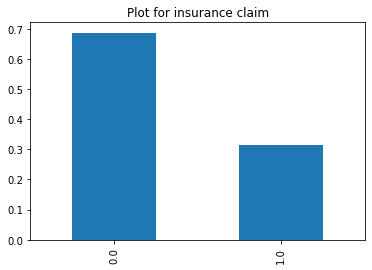

```python
## Checking the distribution of OUTCOME
df["OUTCOME"].value_counts(normalize=True).plot(kind="bar", title="Plot for insurance claim")
```

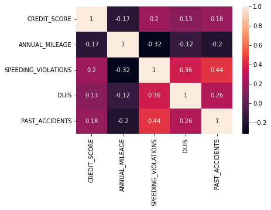

```python
## Correlation matrix between the numerical covariates

correlation_matrix = df.corr().round(2)
sns.heatmap(data=correlation_matrix, annot=True)
```

**We can see significant correlation between some variables like SPEEDING_VIOLATIONS vs PAST_ACCIDENTS etc.

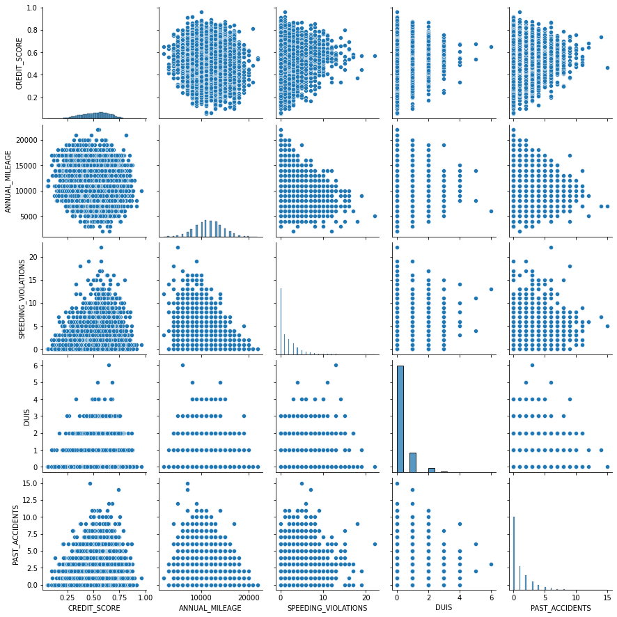

```python
sns.pairplot(data=df)
plt.show()
```

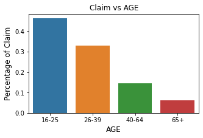

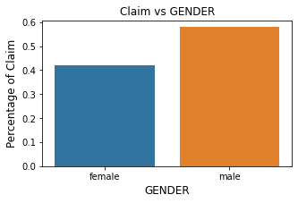

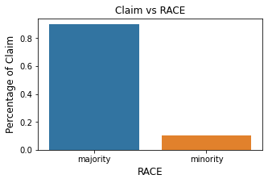

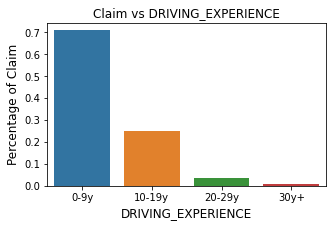

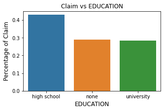

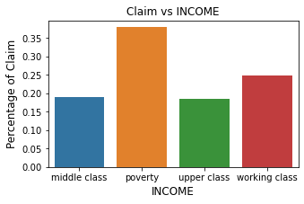

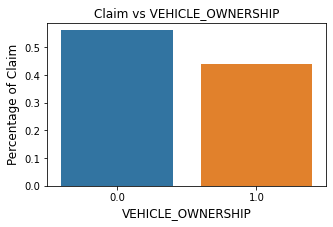

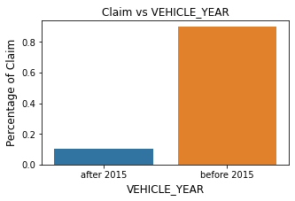

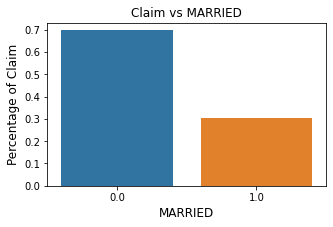

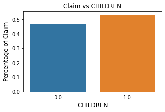

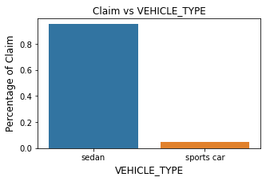

```python
import numpy as np
cols=['AGE', 'GENDER', 'RACE', 'DRIVING_EXPERIENCE', 'EDUCATION', 'INCOME','VEHICLE_OWNERSHIP', 'VEHICLE_YEAR', 'MARRIED',
       'CHILDREN', 'VEHICLE_TYPE']
df1=df[df["OUTCOME"]==1]

for col in cols:
        df2=pd.DataFrame(df1[col].value_counts(normalize=True))
        fig, ax = plt.subplots(figsize = ( 5 , 3 ))
        sns.barplot(ax=ax,data=df2, x= df2.index, y= col)
         # Set label for x-axis
        ax.set_xlabel( col , size = 12 )
         # Set label for y-axis
        ax.set_ylabel( "Percentage of Claim" , size = 12 )
        # Set title for plot
        ax.set_title( "Claim vs "+col , size = 12 )

        plt.show()
```